# Genetic diagnostics

How do clinicians find the correct diagnosis in medical genetics?

Peter N Robinson, Dominik Seelow

Berlin Institute of Health

2026-10-26

## Genetic diagnostics

How do clinicians make a diagnosis of genetic disease?

**1 · Deep phenotyping**  
Detailed clinical examination

**2 · Integrate the evidence**  
Signs, symptoms, lab values, imaging, set against: anatomy biochemistry genetics physiology

**The bottleneck**  
Assembling all the needed information is difficult and time-consuming

**The HRA–HPO bridge** + MutationTaster  
streamlines data integration for clinical diagnostics

Wang Q, et al. (2022) [Deep phenotyping and whole-exome sequencing improved the diagnostic yield for nuclear pedigrees with neurodevelopmental disorders. Mol Genet Genomic Med. 2022 May;10(5):e1918](https://pubmed.ncbi.nlm.nih.gov/35266334/)

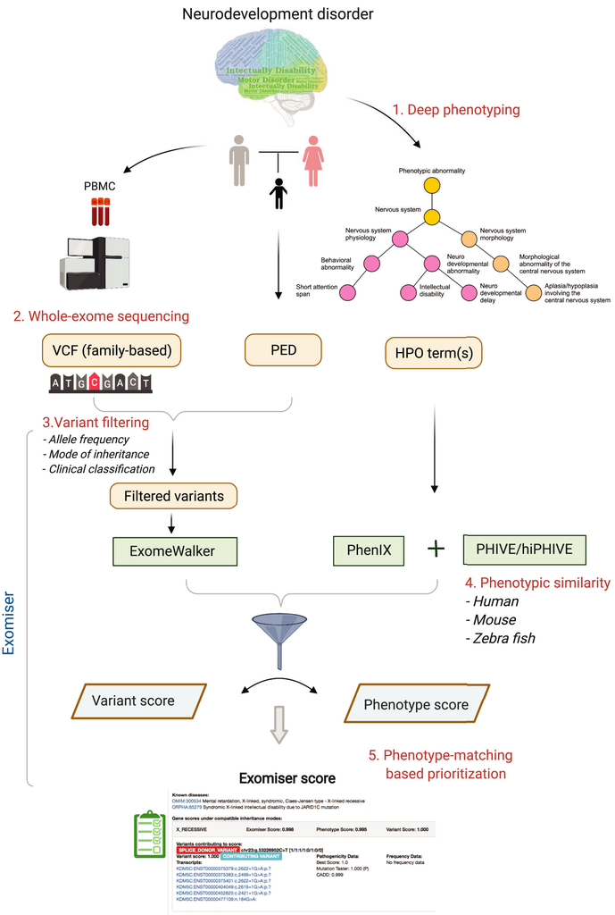

## IPEX syndrome

What can a published IPEX case report teach us about data-driven diagnosis?

**The disease**  
[Immune dysregulation, polyendocrinopathy, enteropathy, X-linked syndrome (IPEX)](https://omim.org/entry/304790)

**The defect**  
A prototypic defect in the natural regulatory T cell compartment, leading to immunodeficiency, autoimmunity, enteropathy and colitis

**The gene**  
Many IPEX patients have defects in the transcription factor *FOXP3*, which determines the fate and immunosuppressive activity of natural and some induced regulatory T cells

Source of the clinical data: Baud O, et al. (2001) [Treatment of the immune dysregulation, polyendocrinopathy, enteropathy, X-linked syndrome (IPEX) by allogeneic bone marrow transplantation. *N Engl J Med* **344**:1758-62](https://pubmed.ncbi.nlm.nih.gov/11396442/)

## Family history

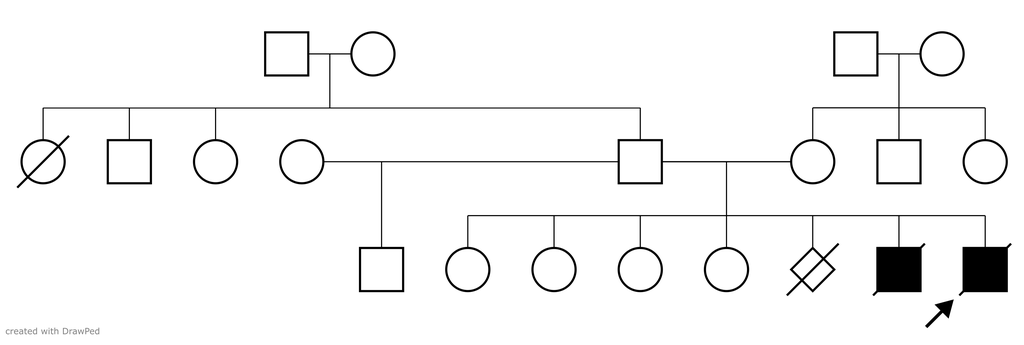

**Mother**  
Unexplained spontaneous abortion in the fourth month of one pregnancy

**Four healthy daughters**  
Aged 11, 16, 18 and 19

No diagnosis was made at the time

## Coding data as HPO

[figure not shown]

## Phenoboard: IPEX Textmining results

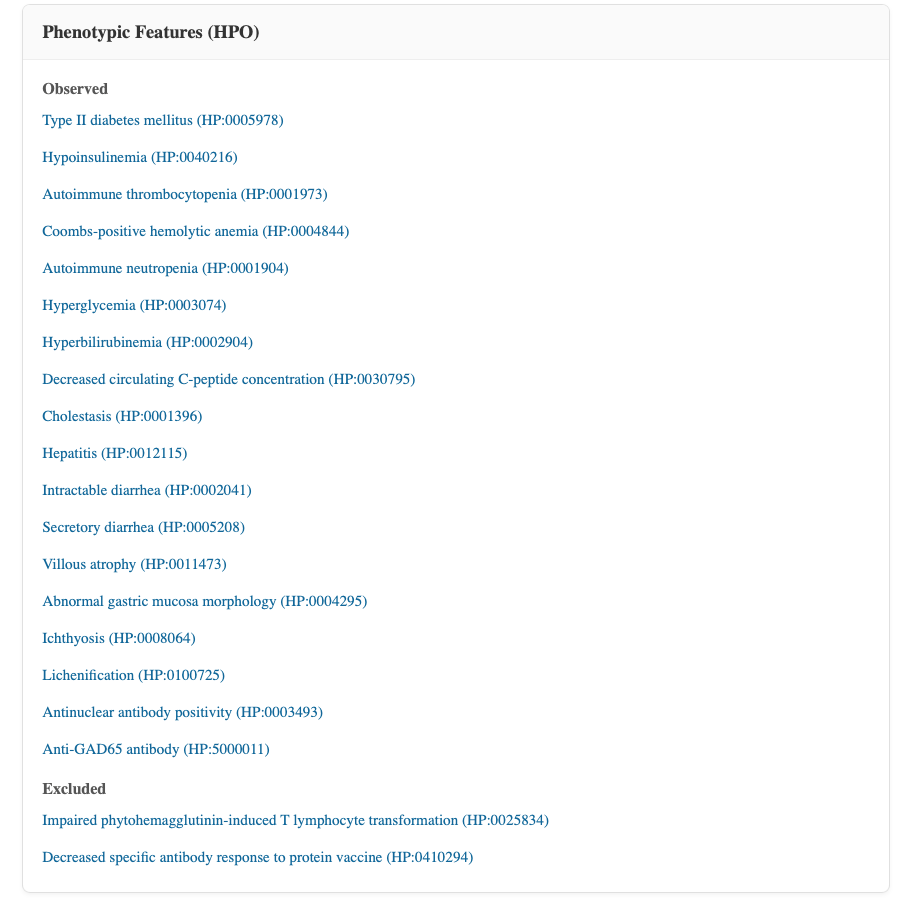

## Differential diagnosis: SAMS

**[Differential diagnosis (SAMS)](https://www.genecascade.org/sams-cgi/phenotype.cgi?phenotype=*HP1873%7C*HP8064%7C*HP100651%7C*HP964%7C*HP2041%7C&age_of_onset=Neonatal%7C&moi=X-linked%20recessive%7C)**  
Ranked candidate diagnoses from the patient’s HPO terms

Steinhaus R, et al. (2022) Deep phenotyping: symptom annotation made simple with SAMS. *Nucleic Acids Res* **50**:W677-W681. [PMID 35524573](https://pubmed.ncbi.nlm.nih.gov/35524573/)